# Value at Risk - interpretacja, zastosowanie, optymalizacja

Market Risk Lab PwC

Nikodem Bujalski

10.05.2026

# 1 Podsumowanie menedżerskie

- Skonstruowano dwa portfele inwestycyjne:
  - portfel o równych wagach (5 spółek),
  - portfel o losowych wagach (5 spółek).
- Analiza punktowego VaR wskazuje, że portfel o równych wagach charakteryzuje się wyższym poziomem ryzyka.
- Różnica ta wynika m.in. z niższego udziału bardziej zmiennych instrumentów (np. Grupa Azoty) w portfelu o losowych wagach.
- VaR rozszerzono do postaci szeregu czasowego, wykorzystując dwa podejścia:
  - okno kroczące (rolling),
  - okno rozszerzające (expanding).
- VaR historyczny okazał się bardziej adekwatny niż VaR parametryczny, który wykazywał tendencję do przeszacowywania ryzyka.
- Podejście z kroczącym oknem danych zapewniło lepsze dopasowanie niż podejście z oknem rozszerzającym, dzięki większej responsywności na zmiany rynkowe.
- Analiza wykazała różnice w strukturze ryzyka:
  - portfel o równych wagach – wyższy przeciętny poziom VaR,
  - portfel o losowych wagach – większa zmienność VaR (bardziej niestabilny profil ryzyka).
- Model GARCH zapewnił najlepsze wyniki spośród analizowanych metod, dzięki uwzględnieniu zmienności warunkowej.
- Wniosek: nie istnieje jedna uniwersalna metoda estymacji VaR – skuteczne zarządzanie ryzykiem wymaga doboru podejścia do charakterystyki danych oraz bieżących warunków rynkowych.

# 2 Wprowadzenie

## 2.1 Cel i zakres

Celem analizy jest porównanie skuteczności różnych podejść do szacowania wartości narażonej na stratę (dalej: VaR, od ang. *Value at Risk*) dla portfeli akcji z rynku polskiego, a także określenie i porównanie poziomu ryzyka analizowanych portfeli.

W praktyce VaR jest jednym z podstawowych narzędzi wykorzystywanych do zarządzania ryzykiem – zarówno w instytucjach finansowych, jak i w analizie portfelowej. Kluczowe pytanie analizy brzmi jednak nie „czym jest VaR”, lecz **która metoda jego estymacji najlepiej odzwierciedla rzeczywiste ryzyko oraz pozwala na wiarygodną ocenę poziomu ryzyka portfela**.

W analizie porównano trzy podejścia:

- **VaR historyczny** – oparty bezpośrednio na obserwowanych stopach zwrotu,
- **VaR parametryczny** – bazujący na założeniu normalności rozkładu,
- **VaR z modelem GARCH** – uwzględniający zmienność w czasie i klastrowanie zmienności.

Ocena metod została przeprowadzona z wykorzystaniem backtestingu, ze szczególnym uwzględnieniem:

- liczby przekroczeń VaR,
- ich niezależności,
- stabilności wyników w czasie.

Celem końcowym jest identyfikacja podejścia, które najtrafniej odwzorowuje rzeczywiste ryzyko portfela, a także umożliwia jego wiarygodną ocenę – szczególnie w warunkach podwyższonej zmienności rynkowej, takich jak napięcia geopolityczne (np. wojna USA z Iranem).

## 2.2 Pochodzenie danych

Dane wykorzystane w analizie pochodzą z wcześniejszego etapu projektu („Przygotowanie danych rynkowych”) i obejmują dzienne ceny zamknięcia dla wybranych spółek notowanych na GPW.

Analizie poddano pięć spółek z sektora przemysłowo-chemicznego:

- Orlen
- KGHM
- PCC Rokita
- Grupa Azoty
- Grupa Kęty

Taki dobór zapewnia umiarkowaną dywersyfikację portfela – spółki działają w powiązanych obszarach gospodarki, ale są jednocześnie narażone na różne czynniki ryzyka (np. ceny surowców, popyt przemysłowy, otoczenie makroekonomiczne).

Na potrzeby analizy ceny zostały przekształcone w logarytmiczne stopy zwrotu, które stanowią podstawę dalszego modelowania ryzyka oraz estymacji VaR.

Załadowanie bibliotek

```r
library(tidyverse)
library(janitor)
library(quantmod)
library(knitr)
library(kableExtra)
library(tseries)
library(moments)
library(slider)
library(rugarch)
```

Załadowanie danych

```r
pcc_raw = read.csv("C:/Users/bujal/Downloads/pcr_d.csv")
azoty_raw = read.csv("C:/Users/bujal/Downloads/att_d.csv")
kety_raw = read.csv("C:/Users/bujal/Downloads/kty_d.csv")
kghm_raw = read.csv("C:/Users/bujal/Downloads/kgh_d (1).csv")
orlen_raw = read.csv("C:/Users/bujal/Downloads/pkn_d.csv")

lista_stooq = list(
  pcc_stooq = pcc_raw,
  azoty_stooq = azoty_raw,
  kety_stooq = kety_raw,
  kghm_stooq = kghm_raw,
  orlen_stooq = orlen_raw
)

oczyszczenie_stooq = function(df) {
  df %>%
    dplyr::select(Data, Zamkniecie) %>%
    rename(date = Data, close = Zamkniecie) %>%
    mutate(date = ymd(date), close = as.numeric(close)) %>%
    arrange(date)
}

stooq_clean = lapply(lista_stooq, oczyszczenie_stooq)
list2env(stooq_clean, envir = .GlobalEnv)

rm(azoty_raw, kety_raw, kghm_raw, orlen_raw, pcc_raw, lista_stooq, stooq_clean)

lista_spolek = list(
  "PCC Rokita"  = pcc_stooq,
  "Grupa Azoty" = azoty_stooq,
  "Grupa Kęty"  = kety_stooq,
  "KGHM"        = kghm_stooq,
  "Orlen"       = orlen_stooq
)

df_long = bind_rows(lista_spolek, .id = "spolka")

df_long = df_long %>%
  group_by(spolka) %>%
  arrange(date, .by_group = TRUE) %>%
  mutate(
    return_rate = (close / lag(close)) - 1,
    log_return = log(close / lag(close))
  ) %>%
  na.omit() %>%
  ungroup()

rm(oczyszczenie_stooq, azoty_stooq, kety_stooq, kghm_stooq, lista_spolek, orlen_stooq, pcc_stooq)

df_wide = df_long %>%
  dplyr::select(date, spolka, return_rate) %>%
  pivot_wider(
    names_from = spolka,
    values_from = return_rate
  ) %>%
  arrange(date) %>%
  clean_names()
```

## 2.3 Portfele inwestycyjne

W analizie wykorzystano dwa podejścia do konstrukcji portfela. Pierwszym z nich jest portfel benchmarkowy oparty na równych wagach.

Równe wagi nie oznaczają jednak zakupu tej samej liczby akcji każdej spółki – ceny poszczególnych walorów znacząco się różnią. W praktyce oznacza to, że kluczowy jest udział, a nie liczba posiadanych akcji.

Aby odzwierciedlić realistyczne warunki inwestycyjne, przyjęto początkową wartość portfela na poziomie 100 000 PLN, którą rozdzielono równomiernie pomiędzy spółki. Każda z nich stanowi zatem 20% portfela (po 20 000 PLN na spółkę).

```r
df_portfolio_equal = df_long %>%
  dplyr::select(date, spolka, return_rate) %>%
  tidyr::pivot_wider(
    names_from = spolka,
    values_from = return_rate
  ) %>%
  janitor::clean_names() %>%
  dplyr::arrange(date) %>%
  dplyr::mutate(
    return_rate =
      0.2 * grupa_azoty +
      0.2 * grupa_kety +
      0.2 * kghm +
      0.2 * orlen +
      0.2 * pcc_rokita,

    log_return_rate = log(1 + return_rate),

    value = 100000 * exp(cumsum(log_return_rate))
  ) %>%
  dplyr::select(date, return_rate, log_return_rate, value)
```

Drugim analizowanym wariantem jest portfel o losowo wygenerowanych wagach, stanowiący alternatywę dla podejścia opartego na równych udziałach.

Wagi portfela zostały wylosowane i kształtują się następująco:  
**Grupa Azoty** = 8,69%  
**Grupa Kęty** = 23,83%  
**KGHM** = 12,36%  
**Orlen** = 26,69%  
**PCC Rokita** = 28,43%

```r
set.seed(123)

w = runif(5)
w = w / sum(w)

df_portfolio_random = df_long %>%
  dplyr::select(date, spolka, return_rate) %>%
  tidyr::pivot_wider(
    names_from = spolka,
    values_from = return_rate
  ) %>%
  janitor::clean_names() %>%
  dplyr::arrange(date) %>%
  dplyr::mutate(
    return_rate =
      w[1] * grupa_azoty +
      w[2] * grupa_kety +
      w[3] * kghm +
      w[4] * orlen +
      w[5] * pcc_rokita,

    log_return_rate = log(1 + return_rate),

    value = 100000 * exp(cumsum(log_return_rate))
  ) %>%
  dplyr::select(date, return_rate, log_return_rate, value)

df_portfolio_equal_250 = df_portfolio_equal %>%
  dplyr::slice_tail(n = 250)

df_portfolio_random_250 = df_portfolio_random %>%
  dplyr::slice_tail(n = 250)
```

# 3 VaR punktowy

## 3.1 Czym jest VaR?

Value at Risk (VaR) to miara ryzyka określająca poziom straty, którego portfel nie powinien przekroczyć z określonym prawdopodobieństwem w danym okresie.

Dla poziomu 95% oznacza to, że w 95% przypadków strata nie przekroczy wyznaczonej wartości. W pozostałych 5% sytuacji straty mogą być wyższe – VaR nie mówi, jak duże, ani nawet jeżeli będą mniejsze to jakie.

W przeciwieństwie do VaR, miary takie jak Expected Shortfall uwzględniają również skalę strat po przekroczeniu tego poziomu.

Najczęściej stosowane poziomy to:  
95% (alfa = 0.05) – standardowy poziom analizy,  
99% (alfa = 0.01) – podejście bardziej konserwatywne.

Obliczenia oparto na logarytmicznych stopach zwrotu ze względu na ich właściwości statystyczne:

- addytywność w czasie,
- większą stabilność szeregu.

Wyniki końcowe prezentowane są w wartościach nominalnych (PLN), w odniesieniu do aktualnej wartości portfela na końcu okresu estymacji.

## 3.2 VaR historyczny

**Czym jest VaR historyczny?**

VaR historyczny to najprostsze podejście do estymacji ryzyka, oparte bezpośrednio na obserwowanych stopach zwrotu.

Metoda polega na wyznaczeniu odpowiedniego kwantyla z rozkładu historycznego. Dla poziomu 95% oznacza to, że VaR odpowiada wartości, poniżej której znajduje się 5% najgorszych wyników.

W praktyce sprowadza się to do uporządkowania historycznych stóp zwrotu i odczytania odpowiedniego percentyla – bez przyjmowania jakichkolwiek założeń dotyczących rozkładu danych.

**Zalety i wady**

Zaletą tego podejścia jest prostota oraz pełne odzwierciedlenie rzeczywistych obserwacji, w tym skrajnych zdarzeń. Jest tutaj znacznie większa odporność na rozkłady danych inne niż normalne, co w świecie finansów jest standardem.

Ograniczeniem jest natomiast brak uwzględnienia zmienności w czasie – metoda traktuje wszystkie obserwacje jednakowo, niezależnie od aktualnej sytuacji rynkowej.

**Analiza wyników**

W poniższej tabeli zaprezentowano obliczony VaR dla obydwu portfeli na obydwu poziomach istotności dla okresu 250 ostatnich dni roboczych.

```r
var_hist = function(df) {
  VaR_95_log = as.numeric(quantile(df$log_return_rate, 0.05))
  VaR_99_log = as.numeric(quantile(df$log_return_rate, 0.01))

  VaR_95 = exp(VaR_95_log) - 1
  VaR_99 = exp(VaR_99_log) - 1

  current_value = tail(df$value, 1)

  VaR_95_pln = abs(VaR_95) * current_value
  VaR_99_pln = abs(VaR_99) * current_value

  data.frame(
    VaR_95 = VaR_95,
    VaR_99 = VaR_99,
    VaR_95_pln = VaR_95_pln,
    VaR_99_pln = VaR_99_pln
  )
}

VaR_equal = var_hist(df_portfolio_equal_250)
VaR_random = var_hist(df_portfolio_random_250)

wyniki_var_hist = rbind(
  data.frame(
    Portfel = "Równe wagi",
    VaR_95 = VaR_equal$VaR_95,
    VaR_99 = VaR_equal$VaR_99,
    VaR_95_pln = VaR_equal$VaR_95_pln,
    VaR_99_pln = VaR_equal$VaR_99_pln
  ),
  data.frame(
    Portfel = "Losowe wagi",
    VaR_95 = VaR_random$VaR_95,
    VaR_99 = VaR_random$VaR_99,
    VaR_95_pln = VaR_random$VaR_95_pln,
    VaR_99_pln = VaR_random$VaR_99_pln
  )
)

wyniki_var_hist = wyniki_var_hist %>%
  dplyr::mutate(
    VaR_95 = paste0(format(round(VaR_95 * 100, 2), nsmall = 2, decimal.mark = ","), "%"),
    VaR_99 = paste0(format(round(VaR_99 * 100, 2), nsmall = 2, decimal.mark = ","), "%"),
    VaR_95_pln = round(VaR_95_pln, 2),
    VaR_99_pln = round(VaR_99_pln, 2)
  )

kable(
  wyniki_var_hist,
  col.names = c(
    "Portfel",
    "VaR 95%",
    "VaR 99%",
    "VaR 95% (PLN)",
    "VaR 99% (PLN)"
  ),
  align = "c",
  caption = "<b style='color:black;'>Tabela 1. VaR historyczny (portfel równy vs losowy).</b>",
  escape = FALSE
) %>%
  kable_styling(
    bootstrap_options = c("condensed"),
    full_width = FALSE,
    position = "center",
    font_size = 15
  ) %>%
  row_spec(0, bold = TRUE, color = "white", background = "#d35400") %>%
  column_spec(1, bold = TRUE, color = "white", background = "#d35400")
```

**Tabela 1. VaR historyczny (portfel równy vs losowy).**

| Portfel | VaR 95% | VaR 99% | VaR 95% (PLN) | VaR 99% (PLN) |
| --- | --- | --- | --- | --- |
| Równe wagi | -1,56% | -2,82% | 2228.94 | 4028.42 |
| Losowe wagi | -1,34% | -2,47% | 1919.67 | 3537.73 |

**Portfel o równych wagach:**  
- VaR 95%: -1,56% (ok. 2229 PLN)  
- VaR 99%: -2,82% (ok. 4028 PLN)

Oznacza to, że na podstawie danych historycznych szacuje się, iż z prawdopodobieństwem 95% dzienna strata portfela w kolejnym dniu nie przekroczy 2229 PLN (oraz 4028 PLN dla poziomu 99%).

**Portfel o losowych wagach:**  
- VaR 95%: -1,34% (ok. 1920 PLN)  
- VaR 99%: -2,47% (ok. 3538 PLN)

Oznacza to, że na podstawie danych historycznych szacuje się, iż z prawdopodobieństwem 95% dzienna strata portfela w kolejnym dniu nie przekroczy 1920 PLN (oraz 3538 PLN dla poziomu 99%).

**Wnioski:**  
- Portfel o równych wagach generuje wyższy poziom VaR zarówno dla 95%, jak i 99%. Może to wynikać m.in. z niższego udziału bardziej zmiennej spółki (Grupa Azoty) w portfelu losowym.  
- Różnice wynoszą ok. 310 PLN (VaR 95%) oraz ok. 490 PLN (VaR 99%). W ujęciu dziennym jest to zauważalna różnica w poziomie ryzyka.  
- Niższy poziom alfa (np. 0,01 zamiast 0,05) oznacza bardziej konserwatywne podejście i wyższe wartości VaR.

**Zastrzeżenia:**  
- VaR historyczny przedstawia prognozowaną granicę straty na kolejny dzień, opartą wyłącznie na danych z przeszłości – nie uwzględnia zmian warunków rynkowych w czasie.  
- Niższy VaR nie oznacza automatycznie „lepszego” portfela – informuje jedynie o poziomie strat w typowych (np. 95%) przypadkach. W pozostałych sytuacjach straty mogą być wyższe.  
- VaR punktowy to pojedyncza wartość oparta na stałym oknie danych, co przy zmienności rynku może prowadzić do niedoszacowania ryzyka.

## 3.3 VaR parametryczny

Kolejnym podejściem do estymacji Value at Risk jest metoda parametryczna, oparta na założeniu konkretnego rozkładu stóp zwrotu – najczęściej rozkładu normalnego.

$$\text{VaR}_{\alpha} = -(\mu_p + z_{\alpha} \cdot \sigma_p)$$

Gdzie:  
* $\mu_p$ – oczekiwana stopa zwrotu portfela (dla horyzontu jednodniowego często przyjmowana jako 0),  
* $\sigma_p$ – odchylenie standardowe stóp zwrotu (miara zmienności),  
* $z_{\alpha}$ – kwantyl rzędu $\alpha$ standardowego rozkładu normalnego (np. dla poziomu 95%: $z_{0.05} \approx -1.645$).

**Jaka jest istota tego podejścia?**  
Podejście to jest szybkie i intuicyjne, jednak opiera się na silnych założeniach, które w praktyce rynkowej często nie są spełnione.

Przede wszystkim zakłada ono normalność rozkładu stóp zwrotu. Tymczasem dane finansowe nawet po przekształceniu do logarytmicznych stóp zwrotu. Zazwyczaj charakteryzują się podwyższoną kurtozą, co oznacza częstsze występowanie zdarzeń skrajnych niż w rozkładzie normalnym.

Dodatkowo metoda zakłada stałą zmienność w czasie. W rzeczywistości zmienność rynkowa ma charakter zmienny i wykazuje tendencję do klastrowania. Okresy spokoju przeplatają się z okresami wysokiej zmienności.

W efekcie VaR parametryczny może:  
- przeszacowywać ryzyko w okresach niskiej zmienności,  
- niedoszacowywać ryzyka w okresach gwałtownych zmian rynkowych.

**Analiza wyników**  
W poniższej tabeli zaprezentowano obliczony VaR dla obydwu portfeli na obydwu poziomach istotności dla okresu 250 ostatnich dni roboczych.

```r
var_param = function(df) {
  mu = mean(df$log_return_rate)
  sigma = sd(df$log_return_rate)

  VaR_95_log = as.numeric(mu + sigma * qnorm(0.05))
  VaR_99_log = as.numeric(mu + sigma * qnorm(0.01))

  VaR_95 = exp(VaR_95_log) - 1
  VaR_99 = exp(VaR_99_log) - 1

  current_value = tail(df$value, 1)

  VaR_95_pln = abs(VaR_95) * current_value
  VaR_99_pln = abs(VaR_99) * current_value

  data.frame(
    VaR_95 = VaR_95,
    VaR_99 = VaR_99,
    VaR_95_pln = VaR_95_pln,
    VaR_99_pln = VaR_99_pln
  )
}

VaR_equal = var_param(df_portfolio_equal_250)
VaR_random = var_param(df_portfolio_random_250)

wyniki_var_param = rbind(
  data.frame(
    Portfel = "Równe wagi",
    VaR_95 = VaR_equal$VaR_95,
    VaR_99 = VaR_equal$VaR_99,
    VaR_95_pln = VaR_equal$VaR_95_pln,
    VaR_99_pln = VaR_equal$VaR_99_pln
  ),
  data.frame(
    Portfel = "Losowe wagi",
    VaR_95 = VaR_random$VaR_95,
    VaR_99 = VaR_random$VaR_99,
    VaR_95_pln = VaR_random$VaR_95_pln,
    VaR_99_pln = VaR_random$VaR_99_pln
  )
)

wyniki_var_param = wyniki_var_param %>%
  dplyr::mutate(
    VaR_95 = paste0(format(round(VaR_95 * 100, 2), nsmall = 2, decimal.mark = ","), "%"),
    VaR_99 = paste0(format(round(VaR_99 * 100, 2), nsmall = 2, decimal.mark = ","), "%"),
    VaR_95_pln = round(VaR_95_pln, 2),
    VaR_99_pln = round(VaR_99_pln, 2)
  )

kable(
  wyniki_var_param,
  col.names = c(
    "Portfel",
    "VaR 95%",
    "VaR 99%",
    "VaR 95% (PLN)",
    "VaR 99% (PLN)"
  ),
  align = "c",
  caption = "<b style='color:black;'>Tabela 2. VaR parametryczny (portfel równy vs losowy).</b>",
  escape = FALSE
) %>%
  kable_styling(
    bootstrap_options = c("condensed"),
    full_width = FALSE,
    position = "center",
    font_size = 15
  ) %>%
  row_spec(0, bold = TRUE, color = "white", background = "#d35400") %>%
  column_spec(1, bold = TRUE, color = "white", background = "#d35400")
```

**Tabela 2. VaR parametryczny (portfel równy vs losowy).**

| Portfel | VaR 95% | VaR 99% | VaR 95% (PLN) | VaR 99% (PLN) |
| --- | --- | --- | --- | --- |
| Równe wagi | -1,83% | -2,66% | 2609.61 | 3787.29 |
| Losowe wagi | -1,65% | -2,40% | 2365.35 | 3443.28 |

**Portfel o równych wagach:**  
- VaR 95%: -1,83% (ok. 2610 PLN)  
- VaR 99%: -2,66% (ok. 3787 PLN)

Oznacza to, że przy założeniu normalności rozkładu stóp zwrotu szacuje się, iż z prawdopodobieństwem 95% dzienna strata portfela w kolejnym dniu nie przekroczy 2610 PLN (oraz 3787 PLN dla poziomu 99%).

**Portfel o losowych wagach:**  
- VaR 95%: -1,65% (ok. 2365 PLN)  
- VaR 99%: -2,40% (ok. 3443 PLN)

Oznacza to, że przy założeniu normalności rozkładu stóp zwrotu szacuje się, iż z prawdopodobieństwem 95% dzienna strata portfela w kolejnym dniu nie przekroczy 2365 PLN (oraz 3443 PLN dla poziomu 99%).

**Wnioski:**  
- Podobnie jak w przypadku VaR historycznego, portfel o równych wagach charakteryzuje się wyższym poziomem ryzyka zarówno dla 95%, jak i 99%.  
- Różnice wynoszą ok. 245 PLN (VaR 95%) oraz ok. 344 PLN (VaR 99%), co wskazuje na umiarkowaną przewagę portfela losowego pod względem ryzyka.  
- W porównaniu do VaR historycznego wartości VaR parametrycznego są bardziej „wygładzone”, co wynika z przyjęcia rozkładu normalnego i wykorzystania jedynie średniej oraz odchylenia standardowego.

**Zastrzeżenia:**  
- VaR parametryczny opiera się na założeniu normalności rozkładu stóp zwrotu, co w praktyce rynkowej często prowadzi do niedoszacowania ryzyka zdarzeń skrajnych.  
- Metoda zakłada stałą zmienność w czasie, przez co może nie reagować odpowiednio na nagłe zmiany warunków rynkowych.  
- Podobnie jak w przypadku VaR historycznego, wynik przedstawia jedynie poziom straty przy zadanym prawdopodobieństwie i nie informuje o skali strat po jego przekroczeniu.  
- Istnieją również rozszerzenia podejścia parametrycznego, wykorzystujące alternatywne rozkłady (np. rozkład t-Studenta), które lepiej odwzorowują grube ogony i zwiększoną częstość zdarzeń skrajnych.

## 3.4 Porównanie metod i portfeli

W celu porównania metod oraz ryzyka portfeli wyniki przedstawiono w tabeli poniżej:

```r
wyniki_var_lacznie = rbind(
  cbind(Metoda = "Historyczny", wyniki_var_hist),
  cbind(Metoda = "Parametryczny", wyniki_var_param)
) %>%
  dplyr::select(Metoda, everything())

kable(
  wyniki_var_lacznie,
  col.names = c(
    "Metoda",
    "Portfel",
    "VaR 95%",
    "VaR 99%",
    "VaR 95% (PLN)",
    "VaR 99% (PLN)"
  ),
  align = "c",
  caption = "<b style='color:black;'>Tabela 3. Porównanie VaR historycznego i parametrycznego.</b>",
  escape = FALSE
) %>%
  kable_styling(
    bootstrap_options = c("condensed"),
    full_width = FALSE,
    position = "center",
    font_size = 15
  ) %>%
  row_spec(0, bold = TRUE, color = "white", background = "#d35400") %>%
  column_spec(1, bold = TRUE, color = "white", background = "#d35400") %>%
  column_spec(2, bold = TRUE)
```

**Tabela 3. Porównanie VaR historycznego i parametrycznego.**

| Metoda | Portfel | VaR 95% | VaR 99% | VaR 95% (PLN) | VaR 99% (PLN) |
| --- | --- | --- | --- | --- | --- |
| Historyczny | Równe wagi | -1,56% | -2,82% | 2228.94 | 4028.42 |
| Historyczny | Losowe wagi | -1,34% | -2,47% | 1919.67 | 3537.73 |
| Parametryczny | Równe wagi | -1,83% | -2,66% | 2609.61 | 3787.29 |
| Parametryczny | Losowe wagi | -1,65% | -2,40% | 2365.35 | 3443.28 |

Wyniki wskazują, że portfel o losowych wagach charakteryzuje się niższym poziomem ryzyka (mierzonego VaR) na obu poziomach istotności oraz w obu zastosowanych metodach. W każdym przypadku osiąga on niższe wartości VaR w porównaniu z portfelem o równych wagach.

**Problem z alfa = 0.01**  
W tym miejscu należy jednak zwrócić uwagę na ograniczenia interpretacyjne poziomu alfa = 0,01. Przy próbie liczącej 250 obserwacji oznacza to statystycznie około 2–3 przekroczenia VaR, co znacząco utrudnia wiarygodną ocenę jakości modelu. W przypadku VaR historycznego dodatkowo prowadzi to do bardzo wąskiego kwantyla, co może skutkować bardziej konserwatywnymi oszacowaniami.

**Ograniczenia VaR**  
Jednocześnie niższy poziom VaR nie daje jednoznacznej odpowiedzi na pytanie, który portfel jest „lepszy”. Miara ta opisuje jedynie poziom strat w typowych warunkach (np. 95% przypadków), pomijając rzadkie, lecz potencjalnie bardzo istotne zdarzenia skrajne. Oznacza to, że mimo niższego VaR portfel może być bardziej narażony na ekstremalne straty.

**Przyczyny**  
Możliwym wyjaśnieniem obserwowanych różnic jest struktura portfela losowego, w szczególności niższy udział spółek o podwyższonej zmienności. Dotyczy to zwłaszcza Grupy Azoty, charakteryzującej się wysoką kurtozą i częstymi skrajnymi wahaniami, oraz KGHM, który wykazuje relatywnie dużą zmienność nawet w okresach spokojnych.

**VaR - historyczny czy parametryczny?**  
W kontekście samej metody trudno jednak jednoznacznie ocenić, która z estymacji VaR lepiej odwzorowuje rzeczywiste ryzyko, opierając się wyłącznie na pojedynczej wartości. Dlatego ocena jakości modeli zostanie przeprowadzona w dalszej części analizy, gdzie VaR zostanie rozszerzony do postaci szeregu czasowego i poddany weryfikacji z wykorzystaniem procedur backtestingowych.

# 4 VaR ciągły

## 4.1 VaR historyczny z rozszerzającym oknem danych

**Dlaczego VaR ciągły?**  
W celu oceny jakości estymacji VaR zastosowano podejście oparte na ciągłej analizie w czasie (backtesting). Pozwala ono sprawdzić, na ile wyznaczone wartości VaR odpowiadają rzeczywistym zmianom wartości portfela.

**Konstrukcja rozszerzającego okna danych**  
Pierwszym analizowanym wariantem jest VaR historyczny z rozszerzającym oknem danych (expanding window). Jego konstrukcja jest analogiczna do punktowego VaR, jednak zamiast pojedynczej wartości estymowany jest cały szereg czasowy, co umożliwia porównanie prognoz z rzeczywistymi stratami.

W analizie wykorzystano poziom istotności alfa = 0,05. Poziom 0,01 został pominięty ze względu na ograniczoną liczbę obserwacji (250), co utrudnia wiarygodną ocenę jakości modelu.

VaR liczony jest w sposób rozszerzający, co oznacza, że dla każdej obserwacji wykorzystywane są wszystkie dostępne dane historyczne do danego momentu. Jednocześnie, w celu zachowania porównywalności z podejściem punktowym, analiza wyników została ograniczona do ostatnich 250 obserwacji.

Każda wartość VaR interpretowana jest jako prognoza maksymalnej jednodniowej straty portfela na kolejny dzień z prawdopodobieństwem 95%.

**Wady rozszrzającego okna danych**  
Metoda ta zakłada jednak równą wagę wszystkich obserwacji w czasie. W praktyce oznacza to, że starsze dane mają taki sam wpływ na wynik jak najnowsze, co może prowadzić do:  
- niedoszacowania ryzyka w okresach nagłego wzrostu zmienności,  
- wygładzania wartości VaR i opóźnionej reakcji na zmiany rynkowe.

**Wyniki analizy**  
Wyniki backtestingu przedstawiono na poniższym wykresie, gdzie porównano rzeczywiste zmiany wartości portfela z prognozowanymi poziomami VaR.

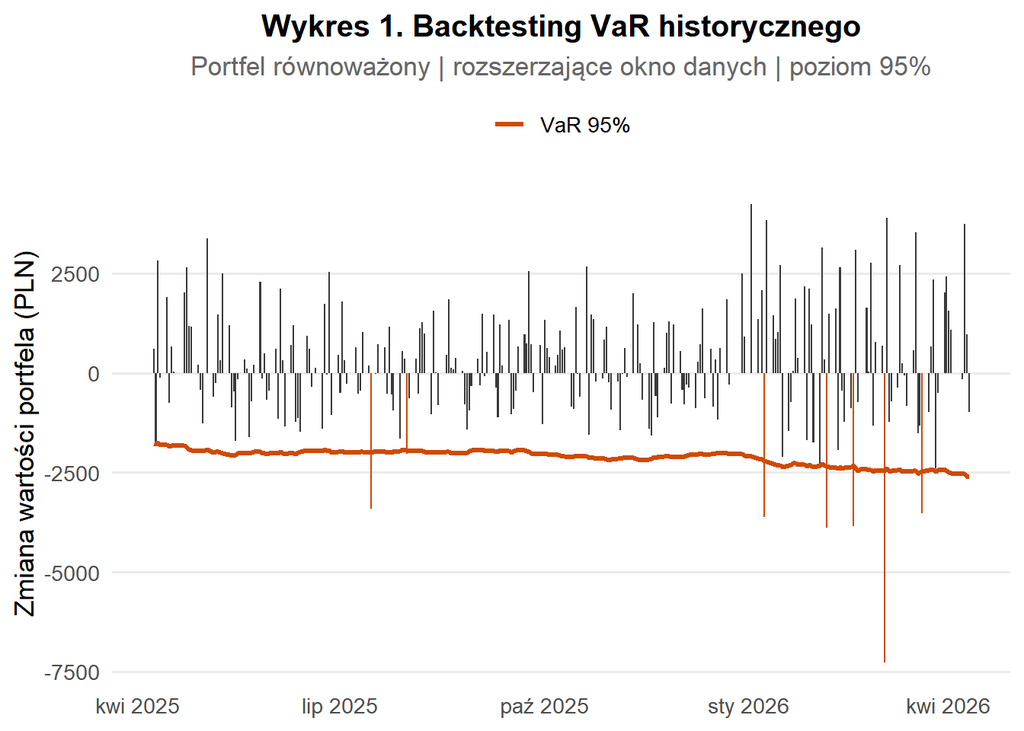

```r
df_var_hist_expanding_equal = df_portfolio_equal %>%
  mutate(
    var_95_log_calc = slider::slide_dbl(
      log_return_rate,
      ~ as.numeric(quantile(.x, 0.05)),
      .before = Inf,
      .complete = TRUE
    ),

    var_95_log_exp = lag(var_95_log_calc, 1),

    var_95_exp = exp(var_95_log_exp) - 1,
    var_95_pln_exp = abs(var_95_exp) * lag(value),
    value_change = value - lag(value)
  ) %>%
  dplyr::filter(!is.na(var_95_exp)) %>%
  slice_tail(n = 250)

ggplot(df_var_hist_expanding_equal, aes(x = date)) +
  geom_col(aes(y = value_change), fill = "#3A3A3A", width = 0.7) +
  geom_col(
    data = df_var_hist_expanding_equal %>%
      dplyr::filter(value_change < -var_95_pln_exp),
    aes(y = value_change),
    fill = "#D04A02",
    width = 0.7
  ) +
  geom_line(aes(y = -var_95_pln_exp, color = "VaR 95%"), linewidth = 1.2) +
  scale_color_manual(
    name = NULL,
    values = c("VaR 95%" = "#D04A02")
  ) +
  labs(
    title = "Wykres 1. Backtesting VaR historycznego",
    subtitle = "Portfel równoważony | rozszerzające okno danych | poziom 95%",
    x = NULL,
    y = "Zmiana wartości portfela (PLN)"
  ) +
  theme_minimal(base_size = 13) +
  theme(
    plot.title = element_text(face = "bold", size = 15, hjust = 0.5),
    plot.subtitle = element_text(color = "gray40", hjust = 0.5),
    legend.position = "top",
    panel.grid.minor = element_blank(),
    panel.grid.major.x = element_blank()
  )
```

Należy podkreślić, że występowanie przekroczeń VaR jest zjawiskiem naturalnym. Model idealny nie polega na ich eliminacji, lecz na utrzymaniu ich liczby na poziomie zgodnym z przyjętym poziomem istotności.

Kluczowe jest znalezienie równowagi pomiędzy nadmierną konserwatywnością a zbyt liberalnym podejściem. Model powinien nie tylko identyfikować okresy podwyższonego ryzyka, ale również pozostawać możliwie blisko typowych, codziennych zmian wartości portfela.

**Przykład:**  
Dobry model jest jak racjonalny człowiek – nie ignoruje sygnałów zagrożenia, ale też nie reaguje skrajnie na każde zdarzenie. Nie jest to ani osoba która gotuje obiad słysząc alarm bombowy, ani osoba siedząca w lesie od 30 lat obawiająca się trzeciej wojny światowej.

**Wnioski:**  
Na podstawie wykresu można stwierdzić, że model jest względnie dobrze dopasowany, jednak posiada istotne ograniczenia. W szczególności widoczny jest okres podwyższonej zmienności (np. związany z napięciami geopolitycznymi), w którym model reaguje z opóźnieniem i nie w pełni odwzorowuje skalę ryzyka.

Dalsza ocena jakości dopasowania zostanie przeprowadzona w podsumowaniu, gdzie wyniki zostaną zestawione dla różnych metod oraz struktur portfela.

## 4.2 VaR historyczny z kroczącym oknem danych

**Czym jest kroczące okno danych?**  
Alternatywnym podejściem do doboru danych jest zastosowanie kroczącego okna (rolling window). W przeciwieństwie do okna rozszerzającego, metoda ta koncentruje się wyłącznie na najnowszych obserwacjach, dzięki czemu lepiej odzwierciedla aktualne warunki rynkowe.

W analizie przyjęto okno o długości 250 obserwacji. Oznacza to, że dla każdej daty VaR estymowany jest na podstawie ostatnich 250 dni, a następnie wykorzystywany do prognozy na kolejny dzień.

Pierwsza wartość VaR wyznaczana jest po zgromadzeniu pełnego okna danych (250 obserwacji), a więc odpowiada prognozie dla dnia następującego po tym okresie. Następnie okno przesuwane jest o jedną obserwację – najstarsza wartość jest usuwana, a najnowsza dodawana – co pozwala na uzyskanie szeregu czasowego VaR.

Każda wartość VaR interpretowana jest jako prognoza maksymalnej jednodniowej straty portfela na kolejny dzień z prawdopodobieństwem 95%.

**Wady kroczącego okna danych:**  
- Podobnie jak w przypadku okna rozszerzającego, wszystkie obserwacje w oknie mają jednakowe wagi, co może ograniczać zdolność modelu do szybkiej reakcji na nagłe zmiany rynkowe.  
- W długich okresach niskiej zmienności metoda może nadmiernie „wygładzać” ryzyko i prowadzić do jego niedoszacowania w momentach nagłych szoków.

**Wyniki analizy**  
Poniżej przedstawiono wyniki analizy VaR historycznego z kroczącym oknem danych dla portfela o równych wagach.

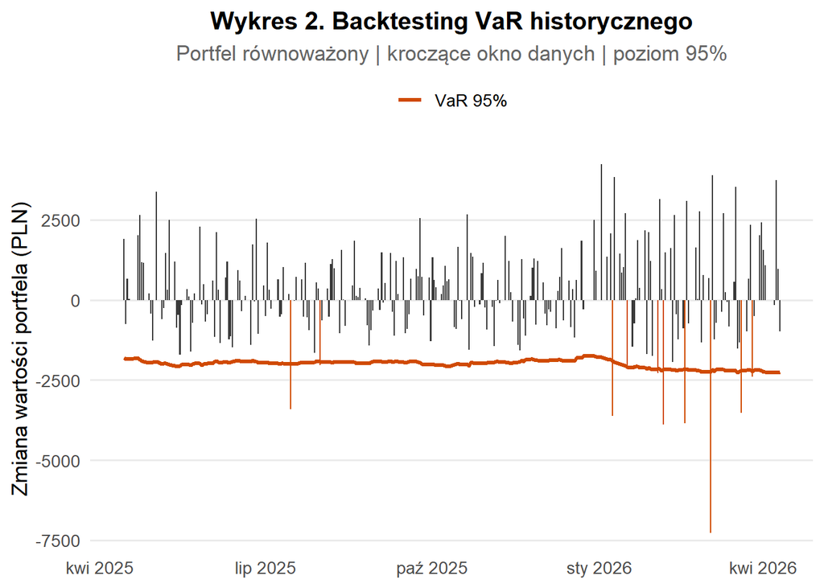

```r
df_var_hist_rolling_equal = df_portfolio_equal %>%
  mutate(
    var_95_log_calc = slider::slide_dbl(
      log_return_rate,
      ~ as.numeric(quantile(.x, 0.05)),
      .before = 249,
      .complete = TRUE
    ),

    var_95_log_roll = lag(var_95_log_calc, 1),

    var_95_roll = exp(var_95_log_roll) - 1,
    var_95_pln_roll = abs(var_95_roll) * lag(value),
    value_change = value - lag(value)
  ) %>%
  dplyr::filter(!is.na(var_95_roll)) %>%
  dplyr::slice_tail(n = 250)

ggplot(df_var_hist_rolling_equal, aes(x = date)) +
  geom_col(aes(y = value_change), fill = "#3A3A3A", width = 0.7) +
  geom_col(
    data = df_var_hist_rolling_equal %>%
      dplyr::filter(value_change < -var_95_pln_roll),
    aes(y = value_change),
    fill = "#D04A02",
    width = 0.7
  ) +
  geom_line(aes(y = -var_95_pln_roll, color = "VaR 95%"), linewidth = 1.2) +
  scale_color_manual(
    name = NULL,
    values = c("VaR 95%" = "#D04A02")
  ) +
  labs(
    title = "Wykres 2. Backtesting VaR historycznego",
    subtitle = "Portfel równoważony | kroczące okno danych | poziom 95%",
    x = NULL,
    y = "Zmiana wartości portfela (PLN)"
  ) +
  theme_minimal(base_size = 13) +
  theme(
    plot.title = element_text(face = "bold", size = 15, hjust = 0.5),
    plot.subtitle = element_text(color = "gray40", hjust = 0.5),
    legend.position = "top",
    panel.grid.minor = element_blank(),
    panel.grid.major.x = element_blank()
  )
```

Wyniki wskazują, że zastosowane metody prowadzą do względnie zbliżonych oszacowań VaR. Różnice pomiędzy nimi są ograniczone w analizowanym okresie, co może wynikać z relatywnie krótkiego horyzontu backtestingu (250 obserwacji).

Bardziej wyraźne rozbieżności widoczne są w zestawieniu zbiorczym, jednak na poziomie szeregu czasowego modele zachowują się podobnie.

Można jednak zauważyć, że VaR z kroczącym oknem danych szybciej reaguje na okresy podwyższonej zmienności, co wskazuje na jego większą wrażliwość na bieżące warunki rynkowe.

## 4.3 VaR parametryczny z rozszerzającym oknem danych

**Konstrukcja:**  
Analogicznie do VaR historycznego z rozszerzającym oknem danych, VaR parametryczny oblicza średnią i odchylenie standardowe z danych oraz rozszrza je o kolejne obserwacje. Najpierw liczy średnią i odchylenie standardowe od dni 1 do 250 w tym zbiorze, a aktualizuje średnią i odchylenie w oparciu o nowe obserwacje.

**Wyniki analizy:**  
Poniżej przedstawiono wyniki analizy VaR parametrycznego z rozszerzającym się oknem danych dla portfela o równych wagach.

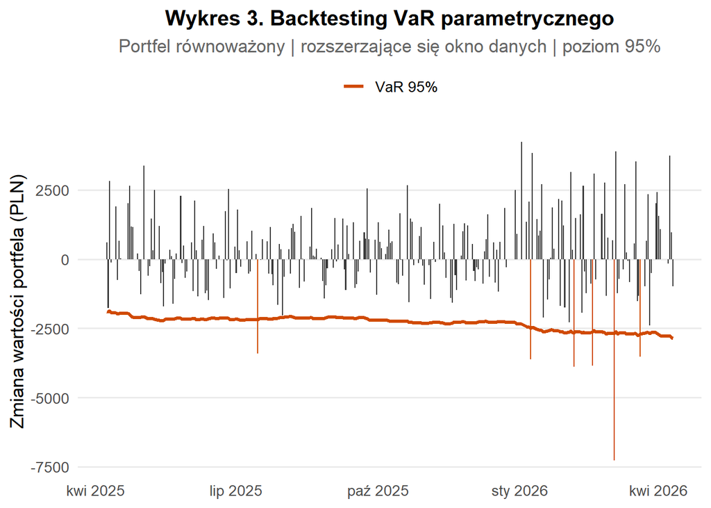

```r
df_var_param_expanding_equal = df_portfolio_equal %>%
  mutate(
    mu_calc = slider::slide_dbl(
      log_return_rate,
      ~ mean(.x),
      .before = Inf,
      .complete = TRUE
    ),
    sigma_calc = slider::slide_dbl(
      log_return_rate,
      ~ sd(.x),
      .before = Inf,
      .complete = TRUE
    ),

    # 2. Obliczamy punktowy VaR na podstawie tych parametrów
    var_95_log_calc = mu_calc + sigma_calc * qnorm(0.05),


    var_95_log_exp = lag(var_95_log_calc, 1),

    var_95_exp = exp(var_95_log_exp) - 1,
    var_95_pln_exp = abs(var_95_exp) * lag(value),
    value_change = value - lag(value)
  ) %>%
  dplyr::filter(!is.na(var_95_exp)) %>%
  dplyr::slice_tail(n = 250)

ggplot(df_var_param_expanding_equal, aes(x = date)) +
  geom_col(aes(y = value_change), fill = "#3A3A3A", width = 0.7) +
  geom_col(
    data = df_var_param_expanding_equal %>%
      dplyr::filter(value_change < -var_95_pln_exp),
    aes(y = value_change),
    fill = "#D04A02",
    width = 0.7
  ) +
  geom_line(aes(y = -var_95_pln_exp, color = "VaR 95%"), linewidth = 1.2) +
  scale_color_manual(
    name = NULL,
    values = c("VaR 95%" = "#D04A02")
  ) +
  labs(
    title = "Wykres 3. Backtesting VaR parametrycznego",
    subtitle = "Portfel równoważony | rozszerzające się okno danych | poziom 95%",
    x = NULL,
    y = "Zmiana wartości portfela (PLN)"
  ) +
  theme_minimal(base_size = 13) +
  theme(
    plot.title = element_text(face = "bold", size = 15, hjust = 0.5),
    plot.subtitle = element_text(color = "gray40", hjust = 0.5),
    legend.position = "top",
    panel.grid.minor = element_blank(),
    panel.grid.major.x = element_blank()
  )
```

Podobnie jak wcześniej, widoczna jest koncentracja przekroczeń w okresach podwyższonej zmienności, natomiast w okresach stabilnych model ma tendencję do przeszacowywania VaR.

**Zastrzeżenia:**  
- Metoda zakłada normalność rozkładu stóp zwrotu, co w praktyce rynkowej często prowadzi do niedoszacowania ryzyka zdarzeń skrajnych.  
- Opiera się na stałej zmienności, przez co nie uwzględnia dynamicznych zmian ryzyka w czasie.  
- W praktyce przypisuje równą wagę obserwacjom (poprzez średnią i odchylenie standardowe), co ogranicza wpływ najnowszych danych, które są kluczowe przy prognozowaniu krótkoterminowego ryzyka.

## 4.4 VaR parametryczny z kroczącym oknem danych

**Konstrukcja:**  
Podejście to łączy założenia VaR parametrycznego z mechanizmem kroczącego okna danych. Oznacza to, że dla każdej obserwacji parametry modelu (średnia oraz odchylenie standardowe) estymowane są na podstawie ostatnich 250 obserwacji, a następnie wykorzystywane do wyznaczenia VaR na kolejny dzień.

W przeciwieństwie do podejścia z oknem rozszerzającym, metoda ta koncentruje się wyłącznie na najnowszych danych, dzięki czemu lepiej odzwierciedla bieżące warunki rynkowe.

Jednocześnie zachowuje wszystkie ograniczenia VaR parametrycznego, w szczególności założenie normalności rozkładu oraz stałej zmienności w obrębie analizowanego okna.

**Wyniki analizy:**  
Poniżej przedstawiono wyniki VaR parametrycznego z kroczącym oknem danych dla portfela o równych wagach.

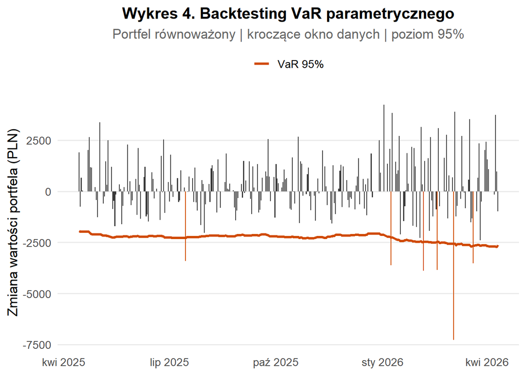

```r
df_var_param_rolling_equal = df_portfolio_equal %>%
  mutate(
    mu_calc = slider::slide_dbl(
      log_return_rate,
      ~ mean(.x),
      .before = 249,
      .complete = TRUE
    ),
    sigma_calc = slider::slide_dbl(
      log_return_rate,
      ~ sd(.x),
      .before = 249,
      .complete = TRUE
    ),
    var_95_log_calc = mu_calc + sigma_calc * qnorm(0.05),
    var_95_log_roll = lag(var_95_log_calc, 1),
    var_95_roll = exp(var_95_log_roll) - 1,
    var_95_pln_roll = abs(var_95_roll) * lag(value),
    value_change = value - lag(value)
  ) %>%
  dplyr::filter(!is.na(var_95_roll)) %>%
  dplyr::slice_tail(n = 250)

ggplot(df_var_param_rolling_equal, aes(x = date)) +
  geom_col(aes(y = value_change), fill = "#3A3A3A", width = 0.7) +
  geom_col(
    data = df_var_param_rolling_equal %>%
      dplyr::filter(value_change < -var_95_pln_roll),
    aes(y = value_change),
    fill = "#D04A02",
    width = 0.7
  ) +
  geom_line(aes(y = -var_95_pln_roll, color = "VaR 95%"), linewidth = 1.2) +
  scale_color_manual(
    name = NULL,
    values = c("VaR 95%" = "#D04A02")
  ) +
  labs(
    title = "Wykres 4. Backtesting VaR parametrycznego",
    subtitle = "Portfel równoważony | kroczące okno danych | poziom 95%",
    x = NULL,
    y = "Zmiana wartości portfela (PLN)"
  ) +
  theme_minimal(base_size = 13) +
  theme(
    plot.title = element_text(face = "bold", size = 15, hjust = 0.5),
    plot.subtitle = element_text(color = "gray40", hjust = 0.5),
    legend.position = "top",
    panel.grid.minor = element_blank(),
    panel.grid.major.x = element_blank()
  )
```

Wyniki są zbliżone do pozostałych podejść, jednak VaR parametryczny z kroczącym oknem danych wykazuje większą zmienność w czasie oraz szybszą reakcję na bieżące warunki rynkowe.

Podobnie jak w innych wariantach, widoczna jest koncentracja przekroczeń w okresach podwyższonej zmienności, co wskazuje na ograniczoną zdolność modelu do uchwycenia nagłych zmian ryzyka.

**Zastrzeżenia:**  
Analogiczne jak w przypadku wcześniej omówionych wariantów VaR parametrycznego oraz kroczącego okna danych.

## 4.5 Porównanie metod dla portfela o równych wagach

```r
# --- HISTORYCZNY EXPANDING ---
rugarch::VaRTest(
  alpha = 0.05,
  actual = df_var_hist_expanding_equal$return_rate,
  VaR = df_var_hist_expanding_equal$var_95_exp
)

# --- HISTORYCZNY ROLLING ---
rugarch::VaRTest(
  alpha = 0.05,
  actual = df_var_hist_rolling_equal$return_rate,
  VaR = df_var_hist_rolling_equal$var_95_roll
)

# --- PARAMETRYCZNY EXPANDING ---
rugarch::VaRTest(
  alpha = 0.05,
  actual = df_var_param_expanding_equal$return_rate,
  VaR = df_var_param_expanding_equal$var_95_exp
)

# --- PARAMETRYCZNY ROLLING ---
rugarch::VaRTest(
  alpha = 0.05,
  actual = df_var_param_rolling_equal$return_rate,
  VaR = df_var_param_rolling_equal$var_95_roll
)
```

[output not shown]

Kluczowym etapem oceny jakości prognoz VaR jest ich walidacja z wykorzystaniem testów statystycznych. Choć nie wszystkie nieprawidłowości są bezpośrednio widoczne na wykresach, testy te pozwalają ocenić, czy model właściwie odwzorowuje poziom ryzyka – w szczególności czy ma tendencję do jego niedoszacowania lub przeszacowania.

W analizie wykorzystano dwa standardowe testy backtestingowe:

1. **Test Kupca (test pokrycia)** – weryfikuje, czy liczba przekroczeń VaR jest zgodna z założonym poziomem istotności.  
   Dla poziomu alfa = 0,05 i 250 obserwacji oczekiwana liczba przekroczeń wynosi około 12. Test pozwala ocenić, czy model systematycznie zaniża lub zawyża ryzyko.
2. **Test Christoffersena (test niezależności)** – bada, czy przekroczenia VaR występują niezależnie w czasie.  
   Pozwala to odróżnić losowe przekroczenia wynikające z naturalnej zmienności rynku od sytuacji, w których model systematycznie nie radzi sobie z określonymi warunkami (np. w okresach kryzysowych).

Dodatkowo w ramach testu Kupca analizowana jest statystyka ilorazu wiarygodności, która stanowi podstawę do oceny zgodności modelu z założeniami statystycznymi.

Tabela porównawcza dla równego portfela

```r
tabela_var = tibble(
  miara = c(
    "Liczba przekroczeń",
    "Oczekiwana liczba przekroczeń",
    "Ostrożność",
    "Niezależność przekroczeń",
    "Jakość prognozy"
  ),
  `Historyczny – rozszerzające okno` = c(
    "7",
    "12",
    "Poprawna",
    "Występuje (p=0.18)",
    "Umiarkowana (3.01)"
  ),
  `Historyczny – okno kroczące` = c(
    "9",
    "12",
    "Poprawna",
    "Występuje (p=0.41)",
    "Wysoka (1.05)"
  ),
  `Parametryczny – rozszerzające okno` = c(
    "6",
    "12",
    "Nadmierna",
    "Występuje (p=0.09)",
    "Niska (4.37)"
  ),
  `Parametryczny – okno kroczące` = c(
    "6",
    "12",
    "Nadmierna",
    "Występuje (p=0.10)",
    "Niska (4.21)"
  )
)

tabela_var_styled = tabela_var %>%
  mutate(across(-miara, ~ case_when(
    . == "Poprawna" ~ cell_spec(., color = "#1E8449", bold = TRUE, format = "html"),
    . == "Nadmierna" ~ cell_spec(., color = "#C0392B", bold = TRUE, format = "html"),
    grepl("^Występuje", .) ~ cell_spec(., color = "#1E8449", bold = TRUE, format = "html"),
    grepl("^Umiarkowana", .) ~ cell_spec(., color = "#B9770E", bold = TRUE, format = "html"),
    grepl("^Niska", .) ~ cell_spec(., color = "#C0392B", bold = TRUE, format = "html"),
    grepl("^Wysoka", .) ~ cell_spec(., color = "#1E8449", bold = TRUE, format = "html"),
    grepl("^Poprawna \\(na granicy\\)", .) ~ cell_spec(., color = "#B9770E", bold = TRUE, format = "html"),
    TRUE ~ .
  )))

kable(
  tabela_var_styled,
  format = "html",
  col.names = c(
    "Miara",
    "Historyczny – rozszerzające okno",
    "Historyczny – okno kroczące",
    "Parametryczny – rozszerzające okno",
    "Parametryczny – okno kroczące"
  ),
  align = "c",
  caption = "<center><b style='color:black;'>Tabela 2. Porównanie jakości modeli VaR dla portfela równoważonego.</b></center>",
  escape = FALSE
) %>%
  kable_styling(
    bootstrap_options = c("condensed"),
    full_width = FALSE,
    position = "center",
    font_size = 15
  ) %>%
  row_spec(0, bold = TRUE, color = "white", background = "#d35400") %>%
  column_spec(1, bold = TRUE, color = "white", background = "#d35400") %>%
  column_spec(2:5, extra_css = "text-align: center; vertical-align: middle;")
```

**Tabela 2. Porównanie jakości modeli VaR dla portfela równoważonego.**

| Miara | Historyczny – rozszerzające okno | Historyczny – okno kroczące | Parametryczny – rozszerzające okno | Parametryczny – okno kroczące |
| --- | --- | --- | --- | --- |
| Liczba przekroczeń | 7 | 9 | 6 | 6 |
| Oczekiwana liczba przekroczeń | 12 | 12 | 12 | 12 |
| Ostrożność | Poprawna | Poprawna | Nadmierna | Nadmierna |
| Niezależność przekroczeń | Występuje (p=0.18) | Występuje (p=0.41) | Występuje (p=0.09) | Występuje (p=0.10) |
| Jakość prognozy | Umiarkowana (3.01) | Wysoka (1.05) | Niska (4.37) | Niska (4.21) |

**Wyniki testów statystycznych:**  
- Wszystkie modele spełniają warunek niezależności przekroczeń (test Christoffersena).  
- Wynik ten może być nieintuicyjny względem obserwacji wykresów.  
- Statystyki testowe znajdują się jednak blisko poziomu istotności, co oznacza, że wynik jest niestabilny i wrażliwy na zmiany danych.

**Ocena modeli:**  
- Modele parametryczne uznano za mniej adekwatne ze względu na:  
- założenie normalności rozkładu,  
- brak uwzględnienia zmienności w czasie,  
- tendencję do przeszacowywania ryzyka.

- Metody historyczne spełniają założenia testów i lepiej odwzorowują dane empiryczne.

**Wybór podejścia:**  
- Spośród metod historycznych lepiej wypada model z kroczącym oknem danych.  
- Jest on bardziej responsywny na bieżące warunki rynkowe i lepiej dopasowany do danych.  
- W przypadku portfela o równych wagach można uznać go za podejście o najwyższej wartości predykcyjnej.

**Ograniczenia:**  
- Wszystkie analizowane modele są relatywnie proste i nie uwzględniają:  
- nieliniowych zależności,  
- zmienności warunkowej.

- W związku z tym ich zdolność predykcyjna jest ograniczona, a wybór najlepszego modelu może zależeć od specyfiki analizowanego okresu, ponieważ jest to znacząco zależne od ilości obserwacji.

## 4.6 Backtesting dla portfela o wagach losowych

Analogicznie do wcześniejszej analizy, przeprowadzono backtesting modeli VaR dla portfela o losowych wagach.

Zastosowano identyczne metody estymacji oraz procedury walidacyjne, dlatego szczegółowa interpretacja nie jest ponownie przedstawiana. Poniżej zaprezentowano wyniki w formie wykresów oraz tabeli.

```r
df_var_hist_rolling_random = df_portfolio_random %>%
  mutate(
    var_95_log_calc = slider::slide_dbl(
      log_return_rate,
      ~ as.numeric(quantile(.x, 0.05)),
      .before = 249,
      .complete = TRUE
    ),
    var_95_log_roll = lag(var_95_log_calc, 1),
    var_95_roll = exp(var_95_log_roll) - 1,
    var_95_pln_roll = abs(var_95_roll) * lag(value),
    value_change = value - lag(value)
  ) %>%
  dplyr::filter(!is.na(var_95_roll)) %>%
  dplyr::slice_tail(n = 250)

df_var_param_expanding_random = df_portfolio_random %>%
  mutate(
    mu_calc = slider::slide_dbl(
      log_return_rate,
      ~ mean(.x),
      .before = Inf,
      .complete = TRUE
    ),
    sigma_calc = slider::slide_dbl(
      log_return_rate,
      ~ sd(.x),
      .before = Inf,
      .complete = TRUE
    ),
    var_95_log_calc = mu_calc + sigma_calc * qnorm(0.05),
    var_95_log_exp = lag(var_95_log_calc, 1),
    var_95_exp = exp(var_95_log_exp) - 1,
    var_95_pln_exp = abs(var_95_exp) * lag(value),
    value_change = value - lag(value)
  ) %>%
  dplyr::filter(!is.na(var_95_exp)) %>%
  dplyr::slice_tail(n = 250)

df_var_param_rolling_random = df_portfolio_random %>%
  mutate(
    mu_calc = slider::slide_dbl(
      log_return_rate,
      ~ mean(.x),
      .before = 249,
      .complete = TRUE
    ),
    sigma_calc = slider::slide_dbl(
      log_return_rate,
      ~ sd(.x),
      .before = 249,
      .complete = TRUE
    ),
    var_95_log_calc = mu_calc + sigma_calc * qnorm(0.05),
    var_95_log_roll = lag(var_95_log_calc, 1),
    var_95_roll = exp(var_95_log_roll) - 1,
    var_95_pln_roll = abs(var_95_roll) * lag(value),
    value_change = value - lag(value)
  ) %>%
  dplyr::filter(!is.na(var_95_roll)) %>%
  dplyr::slice_tail(n = 250)
```

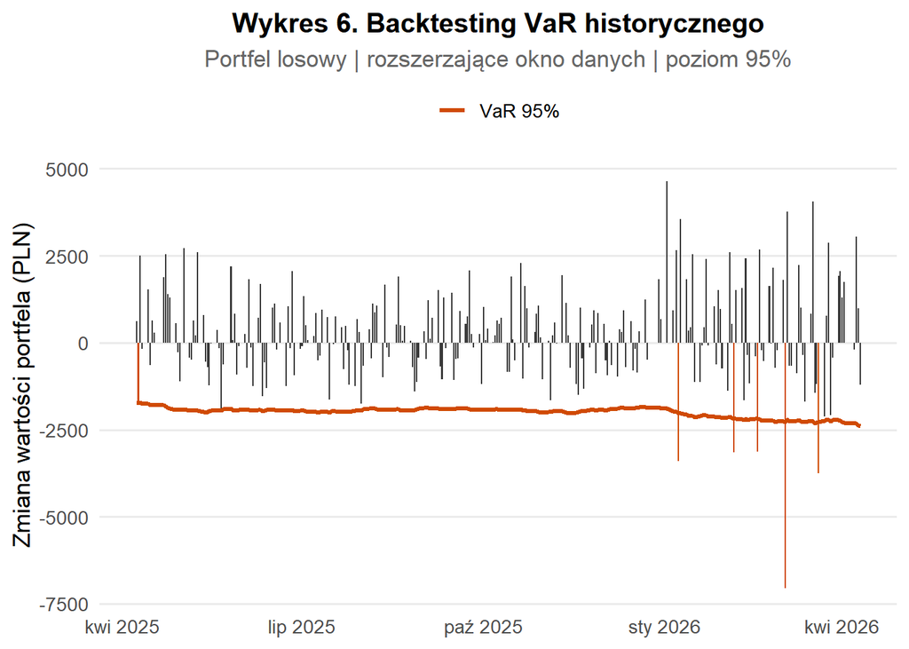

```r
df_var_hist_expanding_random = df_portfolio_random %>%
  mutate(
    var_95_log_calc = slider::slide_dbl(
      log_return_rate,
      ~ as.numeric(quantile(.x, 0.05)),
      .before = Inf,
      .complete = TRUE
    ),
    var_95_log_exp = lag(var_95_log_calc, 1),
    var_95_exp = exp(var_95_log_exp) - 1,
    var_95_pln_exp = abs(var_95_exp) * lag(value),
    value_change = value - lag(value)
  ) %>%
  dplyr::filter(!is.na(var_95_exp)) %>%
  dplyr::slice_tail(n = 250)

ggplot(df_var_hist_expanding_random, aes(x = date)) +
  geom_col(aes(y = value_change), fill = "#3A3A3A", width = 0.7) +
  geom_col(
    data = df_var_hist_expanding_random %>%
      dplyr::filter(value_change < -var_95_pln_exp),
    aes(y = value_change),
    fill = "#D04A02",
    width = 0.7
  ) +
  geom_line(aes(y = -var_95_pln_exp, color = "VaR 95%"), linewidth = 1.2) +
  scale_color_manual(
    name = NULL,
    values = c("VaR 95%" = "#D04A02")
  ) +
  labs(
    title = "Wykres 6. Backtesting VaR historycznego",
    subtitle = "Portfel losowy | rozszerzające okno danych | poziom 95%",
    x = NULL,
    y = "Zmiana wartości portfela (PLN)"
  ) +
  theme_minimal(base_size = 13) +
  theme(
    plot.title = element_text(face = "bold", size = 15, hjust = 0.5),
    plot.subtitle = element_text(color = "gray40", hjust = 0.5),
    legend.position = "top",
    panel.grid.minor = element_blank(),
    panel.grid.major.x = element_blank()
  )
```

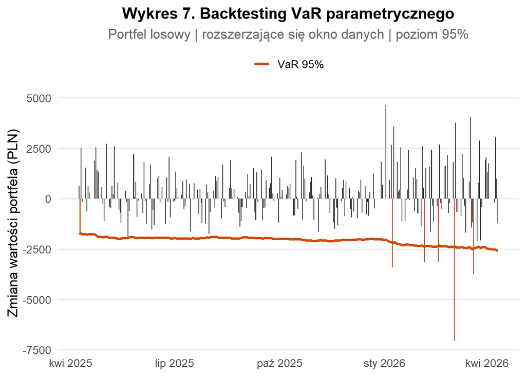

```r
df_var_param_expanding_random = df_portfolio_random %>%
  mutate(
    mu_calc = slider::slide_dbl(
      log_return_rate,
      ~ mean(.x),
      .before = Inf,
      .complete = TRUE
    ),
    sigma_calc = slider::slide_dbl(
      log_return_rate,
      ~ sd(.x),
      .before = Inf,
      .complete = TRUE
    ),
    var_95_log_calc = mu_calc + sigma_calc * qnorm(0.05),
    var_95_log_exp = lag(var_95_log_calc, 1),
    var_95_exp = exp(var_95_log_exp) - 1,
    var_95_pln_exp = abs(var_95_exp) * lag(value),
    value_change = value - lag(value)
  ) %>%
  dplyr::filter(!is.na(var_95_exp)) %>%
  dplyr::slice_tail(n = 250)

ggplot(df_var_param_expanding_random, aes(x = date)) +
  geom_col(aes(y = value_change), fill = "#3A3A3A", width = 0.7) +
  geom_col(
    data = df_var_param_expanding_random %>%
      dplyr::filter(value_change < -var_95_pln_exp),
    aes(y = value_change),
    fill = "#D04A02",
    width = 0.7
  ) +
  geom_line(aes(y = -var_95_pln_exp, color = "VaR 95%"), linewidth = 1.2) +
  scale_color_manual(
    name = NULL,
    values = c("VaR 95%" = "#D04A02")
  ) +
  labs(
    title = "Wykres 7. Backtesting VaR parametrycznego",
    subtitle = "Portfel losowy | rozszerzające się okno danych | poziom 95%",
    x = NULL,
    y = "Zmiana wartości portfela (PLN)"
  ) +
  theme_minimal(base_size = 13) +
  theme(
    plot.title = element_text(face = "bold", size = 15, hjust = 0.5),
    plot.subtitle = element_text(color = "gray40", hjust = 0.5),
    legend.position = "top",
    panel.grid.minor = element_blank(),
    panel.grid.major.x = element_blank()
  )
```

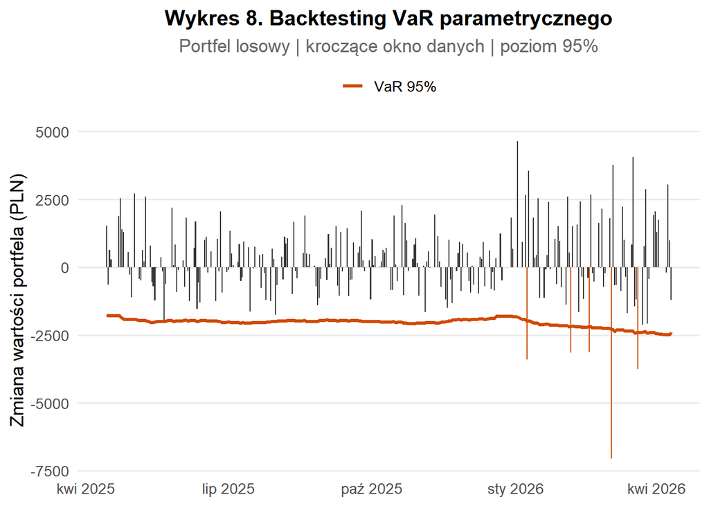

```r
df_var_param_rolling_random = df_portfolio_random %>%
  mutate(
    mu_calc = slider::slide_dbl(
      log_return_rate,
      ~ mean(.x),
      .before = 249,
      .complete = TRUE
    ),
    sigma_calc = slider::slide_dbl(
      log_return_rate,
      ~ sd(.x),
      .before = 249,
      .complete = TRUE
    ),
    var_95_log_calc = mu_calc + sigma_calc * qnorm(0.05),
    var_95_log_roll = lag(var_95_log_calc, 1),
    var_95_roll = exp(var_95_log_roll) - 1,
    var_95_pln_roll = abs(var_95_roll) * lag(value),
    value_change = value - lag(value)
  ) %>%
  dplyr::filter(!is.na(var_95_roll)) %>%
  dplyr::slice_tail(n = 250)

ggplot(df_var_param_rolling_random, aes(x = date)) +
  geom_col(aes(y = value_change), fill = "#3A3A3A", width = 0.7) +
  geom_col(
    data = df_var_param_rolling_random %>%
      dplyr::filter(value_change < -var_95_pln_roll),
    aes(y = value_change),
    fill = "#D04A02",
    width = 0.7
  ) +
  geom_line(aes(y = -var_95_pln_roll, color = "VaR 95%"), linewidth = 1.2) +
  scale_color_manual(
    name = NULL,
    values = c("VaR 95%" = "#D04A02")
  ) +
  labs(
    title = "Wykres 8. Backtesting VaR parametrycznego",
    subtitle = "Portfel losowy | kroczące okno danych | poziom 95%",
    x = NULL,
    y = "Zmiana wartości portfela (PLN)"
  ) +
  theme_minimal(base_size = 13) +
  theme(
    plot.title = element_text(face = "bold", size = 15, hjust = 0.5),
    plot.subtitle = element_text(color = "gray40", hjust = 0.5),
    legend.position = "top",
    panel.grid.minor = element_blank(),
    panel.grid.major.x = element_blank()
  )
```

```r
# --- HISTORYCZNY EXPANDING ---
rugarch::VaRTest(
  alpha = 0.05,
  actual = df_var_hist_expanding_random$return_rate,
  VaR = df_var_hist_expanding_random$var_95_exp
)

# --- HISTORYCZNY ROLLING ---
rugarch::VaRTest(
  alpha = 0.05,
  actual = df_var_hist_rolling_random$return_rate,
  VaR = df_var_hist_rolling_random$var_95_roll
)

# --- PARAMETRYCZNY EXPANDING ---
rugarch::VaRTest(
  alpha = 0.05,
  actual = df_var_param_expanding_random$return_rate,
  VaR = df_var_param_expanding_random$var_95_exp
)

# --- PARAMETRYCZNY ROLLING ---
rugarch::VaRTest(
  alpha = 0.05,
  actual = df_var_param_rolling_random$return_rate,
  VaR = df_var_param_rolling_random$var_95_roll
)
```

```r
tabela_var_random = tibble(
  miara = c(
    "Liczba przekroczeń",
    "Oczekiwana liczba przekroczeń",
    "Ostrożność",
    "Niezależność przekroczeń",
    "Jakość prognozy"
  ),
  `Historyczny – rozszerzające okno` = c(
    "5",
    "12",
    "nadmierna",
    "nie występuje (p = 0.04)",
    "Niska (6.07)"
  ),
  `Historyczny – okno kroczące` = c(
    "7",
    "12",
    "poprawna",
    "występuje (p = 0.10)",
    "Umiarkowana (2.87)"
  ),
  `Parametryczny – rozszerzające okno` = c(
    "5",
    "12",
    "nadmierna",
    "nie występuje (p = 0.04)",
    "Niska (6.07)"
  ),
  `Parametryczny – okno kroczące` = c(
    "5",
    "12",
    "nadmierna",
    "nie występuje (p = 0.04)",
    "Niska (5.89)"
  )
)

tabela_var_random_styled = tabela_var_random %>%
  mutate(across(-miara, ~ case_when(
    . == "poprawna" ~ cell_spec(., color = "#1E8449", bold = TRUE, format = "html"),
    . == "nadmierna" ~ cell_spec(., color = "#C0392B", bold = TRUE, format = "html"),
    grepl("^występuje", .) ~ cell_spec(., color = "#1E8449", bold = TRUE, format = "html"),
    grepl("^nie występuje", .) ~ cell_spec(., color = "#C0392B", bold = TRUE, format = "html"),
    grepl("^Umiarkowana", .) ~ cell_spec(., color = "#B9770E", bold = TRUE, format = "html"),
    grepl("^Niska", .) ~ cell_spec(., color = "#C0392B", bold = TRUE, format = "html"),
    grepl("^Wysoka", .) ~ cell_spec(., color = "#1E8449", bold = TRUE, format = "html"),
    TRUE ~ .
  )))

kable(
  tabela_var_random_styled,
  format = "html",
  col.names = c(
    "Miara",
    "Historyczny – rozszerzające okno",
    "Historyczny – okno kroczące",
    "Parametryczny – rozszerzające okno",
    "Parametryczny – okno kroczące"
  ),
  align = "c",
  caption = "<center><b style='color:black;'>Tabela 3. Porównanie jakości modeli VaR dla portfela o losowych wagach.</b></center>",
  escape = FALSE
) %>%
  kable_styling(
    bootstrap_options = c("condensed"),
    full_width = FALSE,
    position = "center",
    font_size = 15
  ) %>%
  row_spec(0, bold = TRUE, color = "white", background = "#d35400") %>%
  column_spec(1, bold = TRUE, color = "white", background = "#d35400") %>%
  column_spec(2:5, extra_css = "text-align: center; vertical-align: middle;")
```

**Tabela 3. Porównanie jakości modeli VaR dla portfela o losowych wagach.**

| Miara | Historyczny – rozszerzające okno | Historyczny – okno kroczące | Parametryczny – rozszerzające okno | Parametryczny – okno kroczące |
| --- | --- | --- | --- | --- |
| Liczba przekroczeń | 5 | 7 | 5 | 5 |
| Oczekiwana liczba przekroczeń | 12 | 12 | 12 | 12 |
| Ostrożność | nadmierna | poprawna | nadmierna | nadmierna |
| Niezależność przekroczeń | nie występuje (p = 0.04) | występuje (p = 0.10) | nie występuje (p = 0.04) | nie występuje (p = 0.04) |
| Jakość prognozy | Niska (6.07) | Umiarkowana (2.87) | Niska (6.07) | Niska (5.89) |

**Główne obserwacje:**  
- Portfel o losowych wagach okazał się trudniejszy do modelowania ryzyka – większość podejść nie spełnia w pełni kryteriów backtestingu.  
- Jedynym modelem spełniającym założenia testów jest VaR historyczny z kroczącym oknem danych.  
- Nawet w tym przypadku jakość prognozy (test Kupieca) jest umiarkowana, a wynik testu niezależności przekroczeń znajduje się blisko poziomu odrzucenia hipotezy zerowej.

**Ocena modeli:**  
- Żaden z analizowanych modeli nie zapewnia w pełni satysfakcjonującego odwzorowania ryzyka.  
- VaR historyczny z kroczącym oknem danych można uznać za najlepszy dostępny wariant, jednak jego skuteczność pozostaje ograniczona.

**Mocne strony wybranego podejścia:**  
- wykorzystanie empirycznego rozkładu danych (lepsze odwzorowanie rzeczywistości),  
- większa responsywność dzięki koncentracji na najnowszych obserwacjach.

**Kluczowe ograniczenia:**  
- równe traktowanie wszystkich obserwacji w oknie, niezależnie od ich znaczenia,  
- brak uwzględnienia zmienności w czasie (heteroskedastyczności),  
- ograniczona zdolność do uchwycenia dynamiki okresów kryzysowych.

**Implikacje:**  
Wyniki wskazują, że optymalne podejście powinno łączyć:  
- empiryczny rozkład danych,  
- zmienność warunkową (heteroskedastyczność),  
- większą wagę dla najnowszych obserwacji.

## 4.7 Który portfel jest bardziej ryzykowny?

Kluczowe pytanie pozostaje niezmienne – który z analizowanych portfeli charakteryzuje się wyższym poziomem ryzyka.

W tym celu przygotowano zestawienie statystyk opisowych dla wartości VaR uzyskanych przy wykorzystaniu najlepiej dopasowanej metody, tj. VaR historycznego z kroczącym oknem danych.

Analiza obejmuje podstawowe miary, takie jak średnia, mediana oraz odchylenie standardowe, co pozwala na ocenę zarówno przeciętnego poziomu ryzyka, jak i jego zmienności w czasie.

```r
stat_var = function(df, portfel) {
  bind_rows(
    df %>%
      summarise(
        Portfel = portfel,
        Okres = "Cały okres",
        Średnia = mean(abs(var_95_roll) * 100, na.rm = TRUE),
        Mediana = median(abs(var_95_roll) * 100, na.rm = TRUE),
        `Odchylenie standardowe (p.p.)` = sd(abs(var_95_roll) * 100, na.rm = TRUE)
      ),

    df %>%
      slice_tail(n = 60) %>%
      summarise(
        Portfel = portfel,
        Okres = "Ostatnie 60 dni",
        Średnia = mean(abs(var_95_roll) * 100, na.rm = TRUE),
        Mediana = median(abs(var_95_roll) * 100, na.rm = TRUE),
        `Odchylenie standardowe (p.p.)` = sd(abs(var_95_roll) * 100, na.rm = TRUE)
      )
  )
}

tabela_stat_var = bind_rows(
  stat_var(df_var_hist_rolling_equal, "Równe wagi"),
  stat_var(df_var_hist_rolling_random, "Losowe wagi")
) %>%
  mutate(
    across(where(is.numeric), ~ round(.x, 2)),
    Średnia = paste0(format(Średnia, nsmall = 2, decimal.mark = ","), "%"),
    Mediana = paste0(format(Mediana, nsmall = 2, decimal.mark = ","), "%"),
    `Odchylenie standardowe (p.p.)` = format(`Odchylenie standardowe (p.p.)`, nsmall = 2, decimal.mark = ",")
  )

kable(
  tabela_stat_var,
  align = "c",
  caption = "<center><b style='color:black;'>Tabela 4. Statystyki opisowe VaR (model historyczny, okno kroczące).</b></center>",
  escape = FALSE
) %>%
  kable_styling(
    bootstrap_options = c("condensed"),
    full_width = FALSE,
    position = "center",
    font_size = 15
  ) %>%
  row_spec(0, bold = TRUE, color = "white", background = "#d35400") %>%
  column_spec(1, bold = TRUE, color = "white", background = "#d35400") %>%
  column_spec(2, bold = TRUE) %>%
  collapse_rows(columns = 1, valign = "middle")
```

**Tabela 4. Statystyki opisowe VaR (model historyczny, okno kroczące).**

| Portfel | Okres | Średnia | Mediana | Odchylenie standardowe (p.p.) |
| --- | --- | --- | --- | --- |
| Równe wagi | Cały okres | 1,76% | 1,83% | 0,16 |
|  | Ostatnie 60 dni | 1,61% | 1,62% | 0,03 |
| Losowe wagi | Cały okres | 1,62% | 1,61% | 0,24 |
|  | Ostatnie 60 dni | 1,35% | 1,34% | 0,07 |

**Poziom ryzyka (VaR):**  
- Portfel o równych wagach charakteryzuje się wyższym przeciętnym poziomem VaR.  
- Różnice wynoszą ok. 0,14 p.p. dla całego okresu oraz ok. 0,26 p.p. dla ostatnich 60 dni.  
- Wskazuje to na większą ekspozycję na typowe straty w tym portfelu.

**Zmienność ryzyka:**  
- Portfel o losowych wagach wykazuje wyższe odchylenie standardowe VaR.  
- Oznacza to większą zmienność i nieregularność poziomu ryzyka w czasie.  
- Może to utrudniać modelowanie oraz prognozowanie ryzyka.

**Interpretacja:**  
- Niższy poziom VaR nie oznacza automatycznie niższego ryzyka w sensie praktycznym.  
- Portfel o losowych wagach ma bardziej niestabilny profil ryzyka.  
- Ryzyko jest mniej przewidywalne, mimo niższego poziomu średniego VaR.

**Wniosek końcowy:**  
- Portfel o równych wagach jest bardziej ryzykowny pod względem poziomu strat.  
- Portfel o losowych wagach jest bardziej wymagający pod względem zarządzania ryzykiem.  
- Ocena ryzyka powinna uwzględniać zarówno poziom VaR, jak i jego zmienność w czasie.

# 5 Próba zoptymalizowania modelu ryzyka

## 5.1 Istota modelu GARCH

W analizie szeregów czasowych istnieje klasa modeli ukierunkowanych bezpośrednio na estymację zmienności – modele GARCH (Generalized Autoregressive Conditional Heteroskedasticity). W odróżnieniu od wcześniej omawianych podejść koncentrują się one nie na poziomie stóp zwrotu, lecz na dynamice ich zmienności.

Kluczową cechą modelu GARCH jest jego zdolność do szybkiej adaptacji do zmieniających się warunków rynkowych. Zmienność jest aktualizowana na bieżąco, co odzwierciedla fundamentalną właściwość danych finansowych – tendencję do klastrowania zmienności („spokój rodzi spokój, a zmienność rodzi zmienność”).

W praktyce oznacza to, że po wystąpieniu istotnego spadku wartości portfela model natychmiast zwiększa estymowaną zmienność, a tym samym poziom VaR, lepiej odzwierciedlając bieżące ryzyko.

W przeciwieństwie do metod historycznych, GARCH nie traktuje wszystkich obserwacji jednakowo. Dzięki mechanizmowi autoregresji większy wpływ na estymację mają najnowsze dane, co pozwala modelowi „pamiętać” ostatnie wstrząsy rynkowe i skuteczniej identyfikować zjawisko grupowania zmienności.

W efekcie model GARCH reaguje asymetrycznie: - w okresach stabilnych utrzymuje relatywnie niski poziom VaR,  
- w okresach nagłych zmian dynamicznie podnosi poziom ryzyka.

Czyni to podejście bardziej adekwatnym narzędziem do modelowania ryzyka w warunkach zmiennej i niestabilnej zmienności oraz stanowi naturalne rozszerzenie klasycznych metod VaR.

## 5.2 Oszacowanie VaR za pomocą GARCH

Estymacja VaR z wykorzystaniem modelu GARCH wymaga określenia kilku kluczowych elementów modelu:

**Równania średniej** – w analizie przyjęto brak składnika autoregresyjnego (średnia ≈ 0).  
Wynika to z właściwości logarytmicznych stóp zwrotu, które w krótkim okresie oscylują wokół zera i nie wykazują istotnej przewidywalności kierunku zmian.

**Rozkładu teoretycznego stóp zwrotu** – zamiast rozkładu normalnego zastosowano rozkład t-Studenta, który lepiej odwzorowuje grube ogony i częstsze występowanie zdarzeń skrajnych.

**Równania zmienności** – wykorzystano standardową specyfikację modelu GARCH, pozwalającą na modelowanie zmienności warunkowej w czasie.

W kolejnym kroku, w celu poprawy jakości estymacji VaR, wykorzystano empiryczny kwantyl rozkładu (poziom 95%) dla wystandaryzowanych reszt modelu.

Takie podejście pozwala połączyć zalety modelowania zmienności (GARCH) z realistycznym odwzorowaniem rozkładu danych (kwantyl empiryczny).

Wyniki estymacji przedstawiono na wykresie poniżej.

```r
r = df_portfolio_equal$log_return_rate

spec_garch = rugarch::ugarchspec(
  variance.model = list(
    model = "sGARCH",
    garchOrder = c(1, 1)
  ),
  mean.model = list(
    armaOrder = c(0, 0),
    include.mean = TRUE
  ),
  distribution.model = "std"
)

roll_garch = rugarch::ugarchroll(
  spec = spec_garch,
  data = r,
  n.ahead = 1,
  forecast.length = 250,
  refit.every = 1,
  refit.window = "moving",
  window.size = 250,
  solver = "hybrid"
)

df_var_garch_rolling_equal = as.data.frame(roll_garch)
df_var_garch_rolling_equal$date = tail(df_portfolio_equal$date, 250)

df_var_garch_rolling_equal = df_var_garch_rolling_equal %>%
  mutate(
    value = tail(df_portfolio_equal$value, 250),
    value_change = value - lag(value),
    z = (Realized - Mu) / Sigma
  )

z_q_95 = as.numeric(quantile(df_var_garch_rolling_equal$z, 0.05, na.rm = TRUE))

df_var_garch_rolling_equal = df_var_garch_rolling_equal %>%
  mutate(
    VaR_95_log_fhs = Mu + Sigma * z_q_95,
    VaR_95_fhs = exp(VaR_95_log_fhs) - 1,
    VaR_95_pln_fhs = abs(VaR_95_fhs) * lag(value)
  )
```

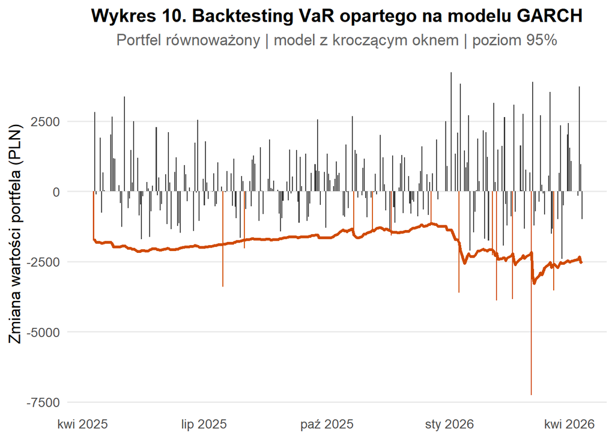

```r
ggplot(df_var_garch_rolling_equal, aes(x = date)) +
  geom_col(aes(y = value_change), fill = "#3A3A3A", width = 0.7) +
  geom_col(
    data = df_var_garch_rolling_equal %>%
      dplyr::filter(value_change < -VaR_95_pln_fhs),
    aes(y = value_change),
    fill = "#D04A02",
    width = 0.7
  ) +
  geom_line(aes(y = -VaR_95_pln_fhs), color = "#D04A02", linewidth = 1.2) +
  labs(
    title = "Wykres 10. Backtesting VaR opartego na modelu GARCH",
    subtitle = "Portfel równoważony | model z kroczącym oknem | poziom 95%",
    x = NULL,
    y = "Zmiana wartości portfela (PLN)"
  ) +
  theme_minimal(base_size = 13) +
  theme(
    plot.title = element_text(face = "bold", size = 15, hjust = 0.5),
    plot.subtitle = element_text(color = "gray40", hjust = 0.5),
    legend.position = "none",
    panel.grid.minor = element_blank(),
    panel.grid.major.x = element_blank()
  )
```

Na podstawie wykresu można zauważyć, że przeciętny poziom VaR w okresach niższej zmienności jest wyraźnie niższy niż w poprzednich podejściach.

Model bardzo dobrze reaguje na nagłe zmiany rynkowe – w okresach szoków dynamicznie zwiększa poziom VaR, dostosowując się do aktualnych warunków. Jednocześnie w okresach stabilnych przekroczenia są ograniczone i nie wykazują nadmiernych odchyleń.

Należy przy tym podkreślić, że występowanie przekroczeń VaR jest zjawiskiem naturalnym i zgodnym z przyjętym poziomem istotności.

W celu pełniejszej oceny jakości modelu przygotowano również zestawienie tabelaryczne oraz przeprowadzono analogiczne testy statystyczne, jak w poprzednich podejściach.

## 5.3 Porównanie modelu GARCH z VaR historycznym (kroczące okno danych) dla portfela o równych wagach

W celu oceny jakości estymacji ryzyka zestawiono wyniki modelu GARCH z najlepszym spośród wcześniej analizowanych podejść, tj. VaR historycznym z kroczącym oknem danych.

```r
rugarch::VaRTest(
  alpha = 0.05,
  actual = df_var_garch_rolling_equal$Realized,
  VaR = df_var_garch_rolling_equal$VaR_95_log_fhs
)
```

```r
tabela_var_final = tibble(
  miara = c(
    "Liczba przekroczeń",
    "Oczekiwana liczba przekroczeń",
    "Ostrożność",
    "Niezależność przekroczeń",
    "Jakość prognozy"
  ),
  `Historyczny – okno kroczące` = c(
    "9",
    "12",
    "poprawna",
    "występuje (p=0.41)",
    "Wysoka (1.05)"
  ),
  `GARCH + rozkład empiryczny` = c(
    "13",
    "12",
    "poprawna",
    "występuje (p=0.48)",
    "Bardzo wysoka (0.20)"
  )
)

tabela_var_final_styled = tabela_var_final %>%
  mutate(across(-miara, ~ case_when(
    . == "poprawna" ~ cell_spec(., color = "#1E8449", bold = TRUE, format = "html"),
    . == "nadmierna" ~ cell_spec(., color = "#C0392B", bold = TRUE, format = "html"),
    grepl("^występuje", .) ~ cell_spec(., color = "#1E8449", bold = TRUE, format = "html"),
    grepl("^nie występuje", .) ~ cell_spec(., color = "#C0392B", bold = TRUE, format = "html"),
    grepl("^Bardzo wysoka", .) ~ cell_spec(., color = "#145A32", bold = TRUE, format = "html"),
    grepl("^Wysoka", .) ~ cell_spec(., color = "#1E8449", bold = TRUE, format = "html"),
    grepl("^Umiarkowana", .) ~ cell_spec(., color = "#B9770E", bold = TRUE, format = "html"),
    grepl("^Niska", .) ~ cell_spec(., color = "#C0392B", bold = TRUE, format = "html"),
    TRUE ~ .
  )))

kable(
  tabela_var_final_styled,
  format = "html",
  col.names = c(
    "Miara",
    "Historyczny – okno kroczące",
    "GARCH + empiryczny"
  ),
  align = "c",
  caption = "<center><b style='color:black;'>Tabela 5. Porównanie VaR: model historyczny (okno kroczące) vs GARCH + rozkład empiryczny.</b></center>",
  escape = FALSE
) %>%
  kable_styling(
    bootstrap_options = c("condensed"),
    full_width = FALSE,
    position = "center",
    font_size = 15
  ) %>%
  row_spec(0, bold = TRUE, color = "white", background = "#d35400") %>%
  column_spec(1, bold = TRUE, color = "white", background = "#d35400") %>%
  column_spec(2:3, extra_css = "text-align: center; vertical-align: middle;")
```

**Tabela 5. Porównanie VaR: model historyczny (okno kroczące) vs GARCH + rozkład empiryczny.**

| Miara | Historyczny – okno kroczące | GARCH + empiryczny |
| --- | --- | --- |
| Liczba przekroczeń | 9 | 13 |
| Oczekiwana liczba przekroczeń | 12 | 12 |
| Ostrożność | poprawna | poprawna |
| Niezależność przekroczeń | występuje (p=0.41) | występuje (p=0.48) |
| Jakość prognozy | Wysoka (1.05) | Bardzo wysoka (0.20) |

**Dopasowanie modelu:**  
- Model GARCH wykazuje wyraźnie lepsze dopasowanie do danych niż VaR historyczny z kroczącym oknem.  
- Lepiej odwzorowuje zarówno okresy stabilne, jak i epizody podwyższonej zmienności.

**Poziom i charakter VaR:**  
- GARCH jest mniej konserwatywny, co przekłada się na wyższy poziom przekroczeń.  
- Jednocześnie liczba przekroczeń jest bardzo zbliżona do wartości oczekiwanej, co wskazuje na właściwe skalibrowanie modelu.

**Wyniki testów statystycznych:**  
- Model GARCH osiąga lepsze wyniki w teście Kupieca, co oznacza wyższą jakość prognozy.  
- Zachowuje również poprawną strukturę przekroczeń w czasie.

**Wniosek końcowy:**  
- Model GARCH, w połączeniu z empirycznym rozkładem danych, stanowi istotne ulepszenie względem wcześniej analizowanych metod.  
- Łączy zalety podejścia historycznego (realistyczny rozkład danych) z modelowaniem zmienności w czasie.  
- W analizowanym przypadku zapewnia najlepszy kompromis pomiędzy dokładnością a stabilnością estymacji ryzyka.

## 5.4 Szacowanie VaR modelem GARCH dla portfela o losowych wagach

Analogicznie przeprowadzono estymację modelu GARCH dla portfela o losowych wagach.

Zastosowano identyczną specyfikację modelu oraz procedurę estymacji, co pozwala na bezpośrednie porównanie wyników z portfelem o równych wagach.

Wyniki przedstawiono na wykresie oraz w tabeli poniżej.

```r
r = df_portfolio_random$log_return_rate

spec_garch = rugarch::ugarchspec(
  variance.model = list(
    model = "sGARCH",
    garchOrder = c(1, 1)
  ),
  mean.model = list(
    armaOrder = c(0, 0),
    include.mean = TRUE
  ),
  distribution.model = "std"
)

roll_garch = rugarch::ugarchroll(
  spec = spec_garch,
  data = r,
  n.ahead = 1,
  forecast.length = 250,
  refit.every = 1,
  refit.window = "moving",
  window.size = 250,
  solver = "hybrid"
)

df_var_garch_rolling_random = as.data.frame(roll_garch)
df_var_garch_rolling_random$date = tail(df_portfolio_random$date, 250)

df_var_garch_rolling_random = df_var_garch_rolling_random %>%
  mutate(
    value = tail(df_portfolio_random$value, 250),
    value_change = value - lag(value),
    z = (Realized - Mu) / Sigma
  )

z_q_95 = as.numeric(quantile(df_var_garch_rolling_random$z, 0.05, na.rm = TRUE))

df_var_garch_rolling_random = df_var_garch_rolling_random %>%
  mutate(
    VaR_95_log_fhs = Mu + Sigma * z_q_95,
    VaR_95_fhs = exp(VaR_95_log_fhs) - 1,
    VaR_95_pln_fhs = abs(VaR_95_fhs) * lag(value)
  )
```

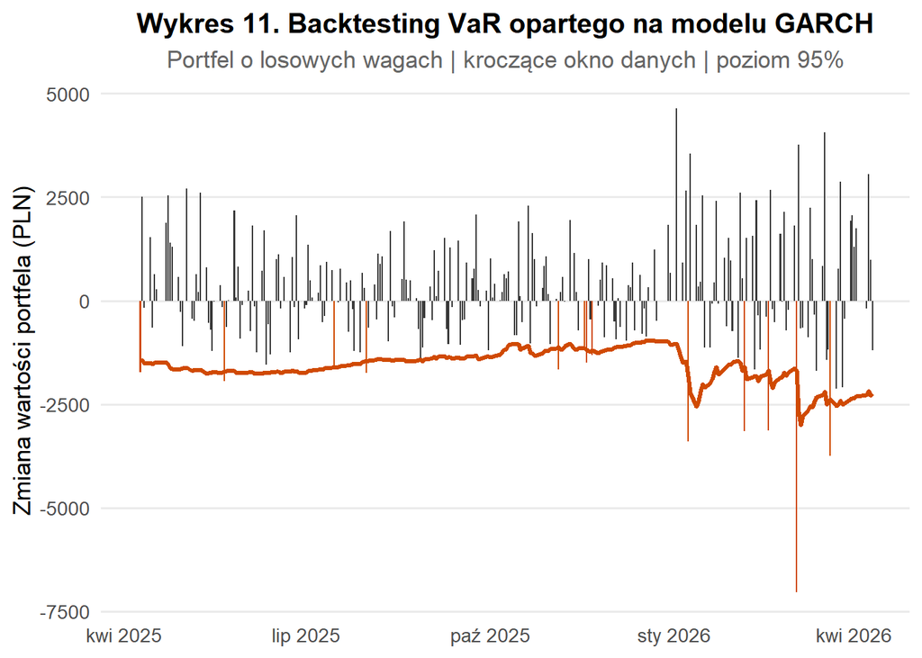

```r
ggplot(df_var_garch_rolling_random, aes(x = date)) +
  geom_col(aes(y = value_change), fill = "#3A3A3A", width = 0.7) +
  geom_col(
    data = df_var_garch_rolling_random %>%
      dplyr::filter(value_change < -VaR_95_pln_fhs),
    aes(y = value_change),
    fill = "#D04A02",
    width = 0.7
  ) +
  geom_line(aes(y = -VaR_95_pln_fhs), color = "#D04A02", linewidth = 1.2) +
  labs(
    title = "Wykres 11. Backtesting VaR opartego na modelu GARCH",
    subtitle = "Portfel o losowych wagach | kroczące okno danych | poziom 95%",
    x = NULL,
    y = "Zmiana wartości portfela (PLN)"
  ) +
  theme_minimal(base_size = 13) +
  theme(
    plot.title = element_text(face = "bold", size = 15, hjust = 0.5),
    plot.subtitle = element_text(color = "gray40", hjust = 0.5),
    legend.position = "none",
    panel.grid.minor = element_blank(),
    panel.grid.major.x = element_blank()
  )
```

```r
rugarch::VaRTest(
  alpha = 0.05,
  actual = df_var_garch_rolling_random$Realized,
  VaR = df_var_garch_rolling_random$VaR_95_log_fhs
)
```

```r
tabela_var_random_final = tibble(
  miara = c(
    "Liczba przekroczeń",
    "Oczekiwana liczba przekroczeń",
    "Ostrożność",
    "Niezależność przekroczeń",
    "Jakość prognozy"
  ),
  `Historyczny – okno kroczące` = c(
    "7",
    "12",
    "poprawna",
    "występuje (p=0.10)",
    "Umiarkowana (2.87)"
  ),
  `GARCH + rozkład empiryczny` = c(
    "13",
    "12",
    "poprawna",
    "występuje (p=0.92)",
    "Bardzo wysoka (0.21)"
  )
)

tabela_var_random_final_styled = tabela_var_random_final %>%
  mutate(across(-miara, ~ case_when(
    . == "poprawna" ~ cell_spec(., color = "#1E8449", bold = TRUE, format = "html"),
    . == "nadmierna" ~ cell_spec(., color = "#C0392B", bold = TRUE, format = "html"),
    grepl("^występuje", .) ~ cell_spec(., color = "#1E8449", bold = TRUE, format = "html"),
    grepl("^nie występuje", .) ~ cell_spec(., color = "#C0392B", bold = TRUE, format = "html"),
    grepl("^Bardzo wysoka", .) ~ cell_spec(., color = "#145A32", bold = TRUE, format = "html"),
    grepl("^Wysoka", .) ~ cell_spec(., color = "#1E8449", bold = TRUE, format = "html"),
    grepl("^Umiarkowana", .) ~ cell_spec(., color = "#B9770E", bold = TRUE, format = "html"),
    grepl("^Niska", .) ~ cell_spec(., color = "#C0392B", bold = TRUE, format = "html"),
    TRUE ~ .
  )))

kable(
  tabela_var_random_final_styled,
  format = "html",
  col.names = c(
    "Miara",
    "Historyczny – okno kroczące",
    "GARCH + empiryczny"
  ),
  align = "c",
  caption = "<center><b style='color:black;'>Tabela 6. Porównanie VaR dla portfela o losowych wagach: model historyczny (rolling) vs GARCH + rozkład empiryczny.</b></center>",
  escape = FALSE
) %>%
  kable_styling(
    bootstrap_options = c("condensed"),
    full_width = FALSE,
    position = "center",
    font_size = 15
  ) %>%
  row_spec(0, bold = TRUE, color = "white", background = "#d35400") %>%
  column_spec(1, bold = TRUE, color = "white", background = "#d35400") %>%
  column_spec(2:3, extra_css = "text-align: center; vertical-align: middle;")
```

**Tabela 6. Porównanie VaR dla portfela o losowych wagach: model historyczny (rolling) vs GARCH + rozkład empiryczny.**

| Miara | Historyczny – okno kroczące | GARCH + empiryczny |
| --- | --- | --- |
| Liczba przekroczeń | 7 | 13 |
| Oczekiwana liczba przekroczeń | 12 | 12 |
| Ostrożność | poprawna | poprawna |
| Niezależność przekroczeń | występuje (p=0.10) | występuje (p=0.92) |
| Jakość prognozy | Umiarkowana (2.87) | Bardzo wysoka (0.21) |

**Główne obserwacje:**  
- Model GARCH utrzymuje wysoką jakość estymacji również dla portfela o wyższej zmienności VaR.  
- Stopień dopasowania jest zbliżony dla obu analizowanych portfeli.  
- Model spełnia założenia testów backtestingowych, co potwierdza jego lepszą kalibrację względem wcześniejszych podejść.

**Wniosek:**  
- GARCH stanowi bardziej precyzyjne narzędzie do estymacji VaR w porównaniu z modelami o stałej zmienności.  
- Lepiej odwzorowuje dynamikę ryzyka oraz reaguje na zmiany warunków rynkowych.

**Zastrzeżenia:**  
- Model GARCH nie stanowi rozwiązania idealnego i nadal posiada istotne ograniczenia.  
- W szczególności może wykazywać opóźnienie reakcji na nagłe załamania rynku (np. jednodniowe opóźnienie przed krachem).  
- Pomimo poprawy względem modeli klasycznych, nadal nie w pełni uchwytuje złożone, nieliniowe zależności rynkowe.

# 6 Podsumowanie

**Implikacje:**  
- W praktyce najbardziej zaawansowane podejścia (np. modele oparte na machine learning) mogą lepiej odwzorowywać złożoność rynku.  
- Jednocześnie ich zastosowanie wiąże się z ograniczoną interpretowalnością, co pozostaje istotnym wyzwaniem w analizie ryzyka.  
- Model GARCH stanowi zatem kompromis pomiędzy jakością estymacji a interpretowalnością wyników.

**Charakterystyka miary VaR:**  
- Value at Risk jest miarą określającą maksymalną stratę przy zadanym poziomie prawdopodobieństwa, a nie jej wartość oczekiwaną.  
- W konsekwencji jego interpretacja wymaga ostrożności, szczególnie w kontekście zdarzeń skrajnych.

**Ocena metod:**  
- Przeanalizowane podejścia różnią się zdolnością do odwzorowania rzeczywistego ryzyka.  
- Najlepsze wyniki osiągnął model GARCH, który jako jedyny uwzględnia zmienność warunkową oraz dynamicznie dostosowuje się do zmian rynkowych.  
- Połączenie GARCH z empirycznym rozkładem danych pozwoliło na uzyskanie najbardziej realistycznych estymacji VaR.

**Porównanie portfeli:**  
- Portfel o równych wagach charakteryzuje się wyższym przeciętnym poziomem VaR.  
- Portfel o losowych wagach wykazuje większą zmienność VaR (wyższe odchylenie standardowe), co oznacza bardziej niestabilny profil ryzyka.  
- W praktyce oznacza to, że ryzyko nie powinno być oceniane wyłącznie przez poziom VaR, ale również przez jego zmienność w czasie.

**Wnioski praktyczne:**  
- Model GARCH stanowi najbardziej adekwatne narzędzie spośród analizowanych metod, jednak nie eliminuje wszystkich ograniczeń modelowania ryzyka.  
- Ocena ryzyka powinna uwzględniać zarówno poziom strat, jak i ich dynamikę.  
- Wybór optymalnego portfela powinien wynikać nie tylko z analizy VaR, ale również z wcześniejszej analizy fundamentalnej i eksploracyjnej danych.

**Konkluzja:**  
- Nie istnieje jedno uniwersalne podejście do modelowania ryzyka.  
- Najlepsze rezultaty osiąga się poprzez łączenie metod oraz uwzględnianie charakterystyki danych i warunków rynkowych.